# Final Análisis Inteligente de Datos

Diego Kozlowski

16 de Agosto 2017

# Introducción

- **Aálisis multivariado sobre estadísticas sociales**
- Es extendido el uso de las herramientas estadísticas y econométricas en el estudio de las condiciones socioeconómicas de los hogares.
- Las herramientas de análisis multivariado tienen menor repercusión
- **Objetivo**: reconocer las potencias, los límites, y la superabilidad de los mismos, de las técnicas de Análisis de Correspondencia Múltiple, Análisis de Componentes Principales, clustering y las regresiones logit, en la respuesta de las preguntas propias del ámbito de las ciencias sociales.

# La Encuesta Permanente de Hogares

“*es un programa nacional de producción sistemática y permanente de indicadores sociales. Releva las características sociodemográficas y socioeconómicas de la población, con énfasis en la medición de los niveles y características del empleo en la Argentina. Proporciona estimaciones válidas para los cuatro trimestres del año y cubre 31 aglomerados urbanos donde habita, aproximadamente, el 70% de la población urbana del país. En su modalidad puntual, la EPH se realiza en Argentina desde el año 1973. A partir del 2003 y hasta la actualidad, la EPH aplica una modalidad continua.*” (INDEC 2016)

- Sobre la base de esta encuesta se elaboran las estadísticas oficiales respecto de la incidencia la **pobreza y la indigencia**, los principales indicadores de **mercado de trabajo** y distribución del ingreso.
- Los micro datos de la encuesta son publicados de forma periódica en dos bases: La *base hogar* (88 variables - 19000 registros) y la *base individual* (177 variables - 60000 registros).
- **Módulos Base Hogar**:
  - *Identificación*
  - *Características de la vivienda*
  - *Características habitacionales del hogar*
  - *Estrategias de supervivencia del hogar*
  - *Ingresos*
  - *Organización del hogar*
- **Base individual**:
  - *Identificación*
  - *cuestionario encadenado*
  - *Condición de actividad*
  - *Nivel educativo*
  - *Ingresos*
  - *características del empleo*
- Para el presente trabajo se decidió tomar sólo una pequeña porción de las variables existentes en ambas bases, además de crear la variable *nivel educativo*

# Técnicas implementadas

## Análisis de Correspondencia Multiple

- *Base Hogar* :
  - **Estrategias de supervivencia de los hogares**:
    - *12 variables* dicotómicas que responden respecto a las formas en que los hogares logran subsistir económicamente.
  - **Características habitacionales de los hogares**:
    - *5 variables* respecto de la cantidad de ambientes, dormitorios, la condición de ocupación. el tipo de cocina y el tipo de baño.
  - **Características habitacionales de las viviendas**:
    - *9 variables* respecto de los materiales utilizados en la vivienda, el acceso al agua, etc.
- *Base Individual*:
  - **Características de los miembros del hogar**:
    - *7 variables* respecto de las características generales de los individuos: edad, categoría ocupacional, condición de actividad, relación de parentesco, etc.

**Reducción de la dimensionalidad**: Se asigno un valor 0 a los pares atributos valor con menor inercia  
* Reduce variables * Reduce cardinalidad * Aumenta la inercia de las primeras dimensiones * Facilita la interpretación

## Análisis de Componentes Principales

- Objetivo: Caracterizar el ingreso de los hogares según tipo, características del puesto y de los individuos.
- Dificultades: baja correlación
- Solución: selección de variables y segmentación.

Se realizaron dos ejercicios:

- análisis de las características de los individuos respecto de sus ingresos
- Análisis de las diferentes formas de ingresos respecto de las características del puesto

## Clustering

- Segundo nivel de análisis
- Aplicado sobre los biplots de análisis de correspondencia múltiple
- k-means sobre las coordenadas
- Diez puntos aleatorios de partida

## Logit

- Objetivo: Estudiar la relación entre las horas trabajadas y la disposición a seguir trabajando
- Variables: 1- Cantidad de horas trabajadas en la semana de referencia. 2- En dicha semana, ¿quería trabajar más horas? (Si, No) 3- Género

## El uso de ponderadores de replicación

- La EPH cuenta con un set de ponderadores que permiten proyectar los resultado muestrales al total de la población urbana.
- No existe un diseño endógeno en la muestra que busque explícitamente sobrerepresentar a una porción de la población
- Los ponderadores se construyen con el objetivo de realizar estimaciones respecto de la población en indicadores del mercado de trabajo, y por lo tanto no fueron pensados desde su diseño para poder expresar la interacción entre las variables, que es lo que se realiza en el presente trabajo.
- No se encuentra en la bibliografía una respuesta única respecto al uso de ponderadores en diseños muestrales complejos(Young, s. f., Le Roux, Brigitte y Rouanet (2010), Cuadras (2014), Peña (2002) y Hastie, Tibshirani, y Friedman (2009)).
- Para regresiones lineales, Solon, Haider, y Wooldridge (2015) plantea que sólo en ciertos casos puntuales, como lo son la presencia de heterocedasticidad, o de un diseño endógeno, es correcto el uso de ponderadores, que por lo demás pueden llegar a generar una mayor variabilidad.
- Se realizaron ejercicios con las tres alternativas:
  - Sin ponderadores
  - Con ponderadores
  - Con Ponderadores normalizados
- Conclusiones:
  1. Es indistinto el uso de ponderadores de replicación y ponderadores normalizados.
  2. Existen diferencias cuando se incorporan ponderadores. Sin embargo, estas son poco significativas. 3.Esto es razonable dado el carácter aleatorio en la selección de la muestra.

Como conclusión, dado que los ponderadores no fueron diseñados para representar la interacción entre las variables, se continúa en el resto del presente trabajo sin hacer uso de los mismos. Sin embargo, se considera un punto pendiente para trabajos futuros comprender más profundamente la implicancia de su utilización.

## Software utilizado

- Software estadístico *R* (R Core Team 2017).  
  **extensiones**:
- Análisis de correspondencia múltiple: *FactoMineR* (Lê, Josse, y Husson 2008).
- Análisis de componentes principales: *R base* y *ggbiplot*(Vu 2015).
- Logit : *ggplot*(Wickham 2009).

# Principales resultados

## Base Hogar

### Estratégias de supervivencia de los hogares

**Tabla 1**

| Variable | Descripción |
| --- | --- |
| V1 | Trabajo |
| mnr.10.pid | Menor de 10 años pidiendo |
| V13 | Ahorros |
| V14 | Pedir a familiares |
| V15 | Pedir a bancos |
| V17 | vender pertenencias |
| V21 | Aguinaldo jubilación |
| V22 | Retroactivo jubilación |
| V3 | Indemnización despido |
| V4 | Seguro de desempleo |
| V8 | Alquiler |
| V9 | Ganancias |

**Gráfico 1**

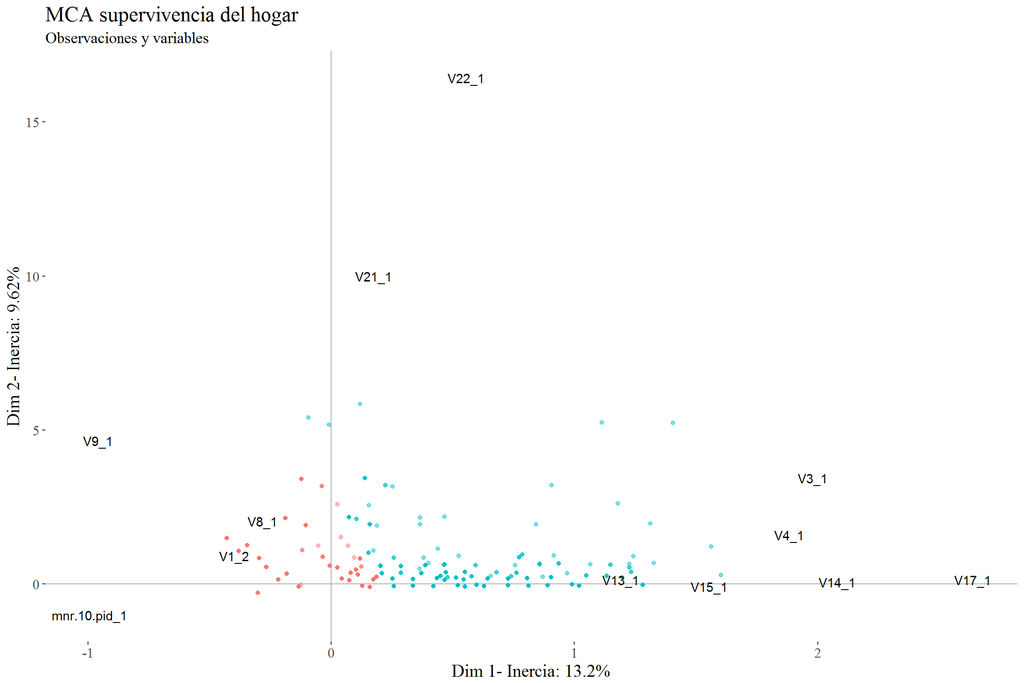

- **Primera dimensión**: Inserción en el mercado de trabajo
  - Perfil medio: Ingresos provenientes del trabajo
  - Valores negativos: Ingresos de ganancias y alquileres
  - Valores positivos: desempleo, subsisten de indemnizaciones, prestamos y desahorro
- **Segunda dimensión**: Segmentación generacional
  - Valores negativos: menores de edad pidiendo
  - Valores positivo: Ingresos de jubilados

### Características habitacionales de los hogares

**Tabla 2**

| Variable | Descripción |
| --- | --- |
| II1 | Ambientes de uso exclusivo |
| II2 | Dormitorios |
| II7_7 | Ocupante, sin permiso |
| II8_3 | cocina a leña/carbón |
| II8_4 | cocina no convencional |
| II9_2 | Baño de uso compartido con otro hogar |
| II9_3 | Baño de uso compartido con otra vivienda |
| II9_4 | No tiene baño |

**Gráfico 2**

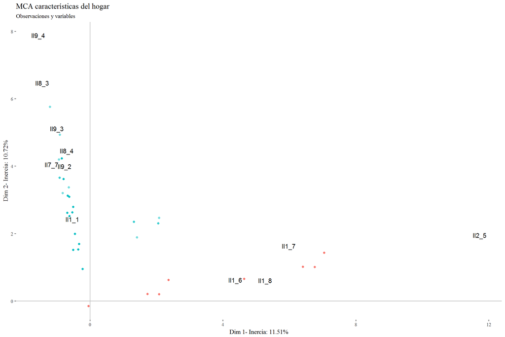

- **Primera dimensión**: Tamaño del hogar
  - Valores negativos: Hogares con pocas habitaciones y dormitorios
  - Valores positivos: Hogares con muchas habitaciones y dormitorios
- **Segunda dimensión**: Precariedad del hogar
  - Es una dimensión de fuerza, a mayor valor, mayor precariedad

Los hogares con problemas habitacionales se encuentran sobre el segundo cuadrante, es decir, tienen menor tamaño.

### Características habitacionales de las viviendas

**Tabla 3**

| Variable | Descripción |
| --- | --- |
| IV1_5 | Local no construido para habitación |
| IV1_6 | Vivienda no convencional |
| IV10_2 | Inodoro a balde |
| IV10_3 | Letrina sin arrastre de agua |
| IV11_4 | Desague a exacavación a tierra |
| IV12_3 | Villa de emergencia |
| IV3_3 | Piso de tierra |
| IV4_6 | Techo de chapa metal |
| IV4_7 | Techo de paja |
| IV6_2 | Agua fuera de la vivienda |
| IV6_3 | Agua fuera del terreno |
| IV7_4 | Agua de fuente no convencional |
| IV9_2 | Baño fuera de la vivienda |

**Gráfico 3**

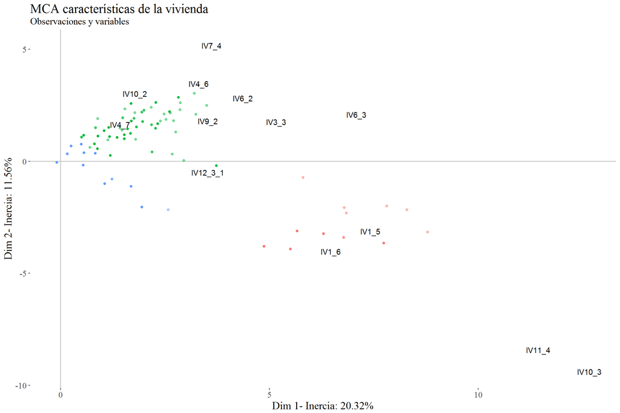

- **Primera dimensión**: Problemas de acceso al agua
  - Es una dimensión de fuerza, a mayor valor, menor acceso al agua
- **Segunda dimensión**: Tipo de Vivienda
  - Valores positivos: casas y departamentos precarios
  - Valores negativos: casillas, construcciones no hechas para habitar, mayormente ubicados en villas de emergencia.
- Se crean tres clusters
  - Azul: Entorno del **perfil medio**: Sin problemas particulares para acceder al agua, casas, departamentos, etc.
  - Verde: **Construcciones precarias**: Pisos de tierra, techos de chapa, pero con algún acceso al agua corriente, no necesariamente ubicados en villas de emergencia.
  - Rojo: **casillas**: construcciones de cilo bolsa, casas precarias, ubicadas en villas de emergencia

## Base individuos

### Características de los miembros del hogar

**Tabla 4**

| Variable | Descripción |
| --- | --- |
| CAT.INAC_5 | Menor de 6 años |
| CAT.OCUP_1 | Partón |
| CAT.OCUP_3 | Asalariado |
| CAT.OCUP_9 | Ns.Nr. |
| CH03_5 | Nieto del jefe de hogar |
| CH08_3 | Seguro Público |
| CH08_123 | Tiene obra social, prepaga y Seguro público |
| CH09_2 | No sabe leer y escribir |
| CH09_3 | Menor de 2 años |
| ESTADO_1 | Ocupado |
| ESTADO_4 | Menor de 10 años |
| Nivel.ED_6 | Universitario completo |
| Nivel.ED_7 | Sin instrucción |

**Gráfico 4**

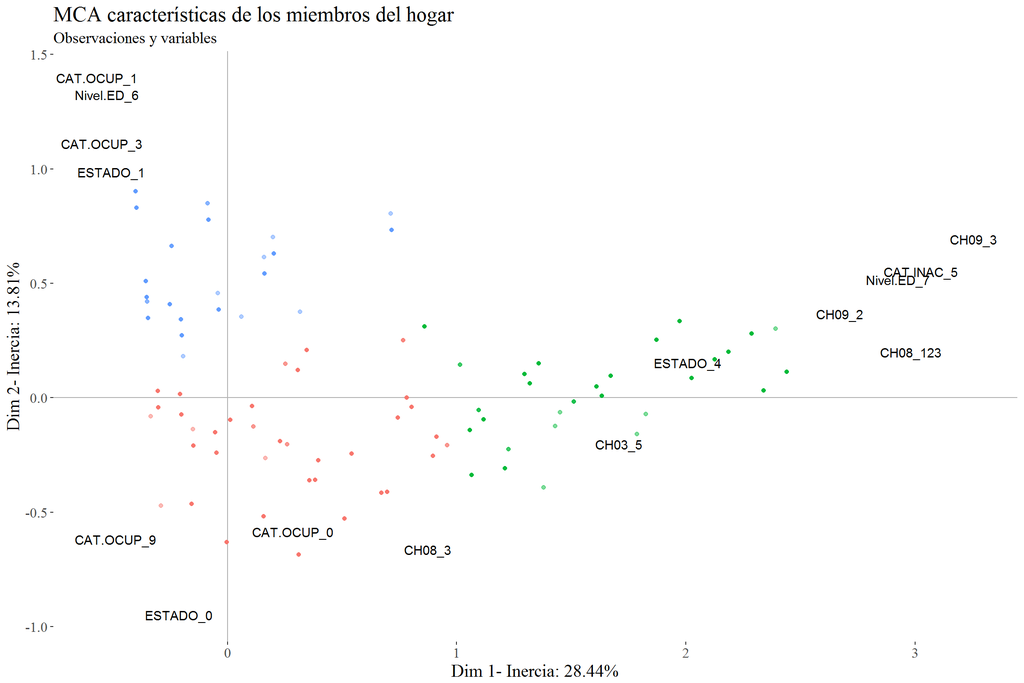

- **Primera dimensión**: Infancia
  - Es una dimensión de fuerza, valores altos indica que son niños pequeños.
- **Segunda dimensión**: Ocupación
  - Valores positivos: Asalariados, patrones, con educación
  - Valores negativos: Miembros del hogar que no participan del mercado de trabajo
- Se crean tres clusters
  - Azul: Ocupados, asalariados o patrones, son los *jefes de hogar*
  - Verde: *menores*: Sin instrucción, con cobertura social, inactivos.
  - Rojo: *demas roles del hogar*: Ni menores, ni jefes de hogar, ocupan un lugar intermedio.

### Ingresos

#### Ingresos y nivel educativo.

**Gráfico 5**

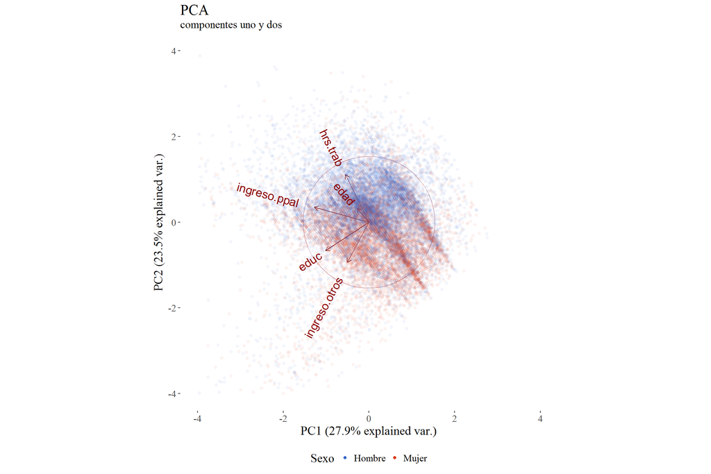

- Las variables más importantes son *Horas trabajadas* y ambos tipos de ingresos.
- Las horas trabajadas se asocian positivamente con los ingresos de ocupación principal y negativamente con los demás ingresos.
- Los varones suelen tener una ocupación principal con mayor carga horaria, mientras que las mujeres suelen tener una menor carga horaria y más ingresos no laborales

**Gráfico 6**

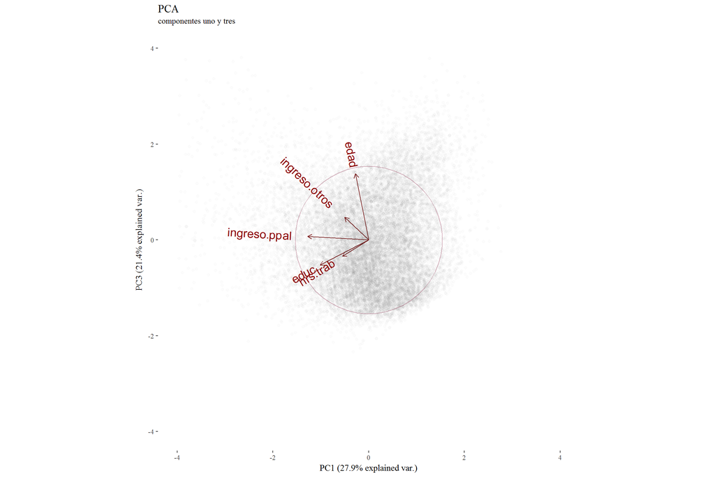

- La educación se asocia fuertemente con las horas trabajadas y negativamente con la edad
- Los ingresos por la ocupación principal se asocian con la educación, y son prácticamente independientes de la edad.

#### Tipos de ingreso

**Gráfico 7**

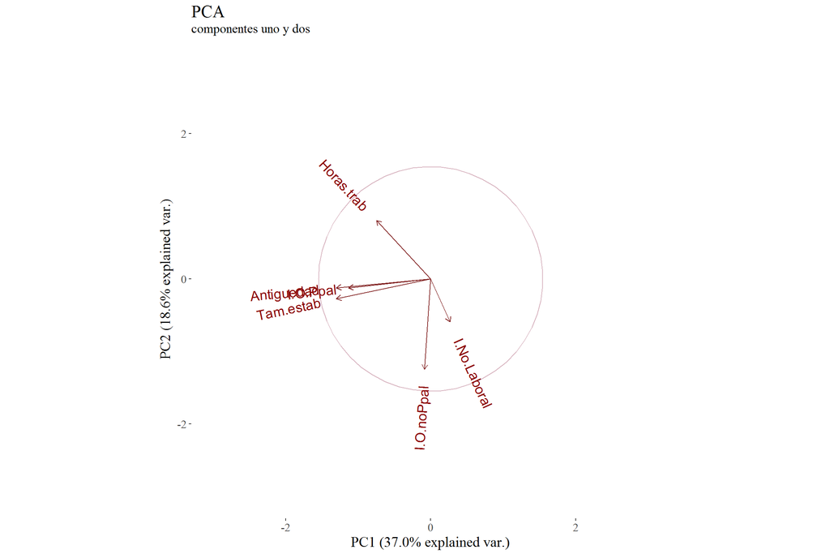

- El primer componente contrasta entre aquellos hogares insertos en el mercado de trabajo, respecto de los hogares que se encuentran fuera del mismo.
- El segundo componente marca el grado de dedicación a la ocupación principal.
  - Los valores negativos indican ingresos no laborales, o ingresos por ocupación secundaria.
  - Los valores positivos marcan muchas horas trabajadas en la ocupación principal.
- Asociación negativa entre las horas trabajadas en la ocupación principal y los ingresos de otras fuentes.
- Asociación positiva entre antigüedad, tamaño del establecimiento y los ingresos por ocupación principal.
- Las horas trabajadas se asocian débilmente a los ingresos.
- Lo relevante para los ingresos altos esta más relacionado a las características del puesto más que a la carga horaria del mismo

### Tiempo de trabajo

**Gráfico 8**

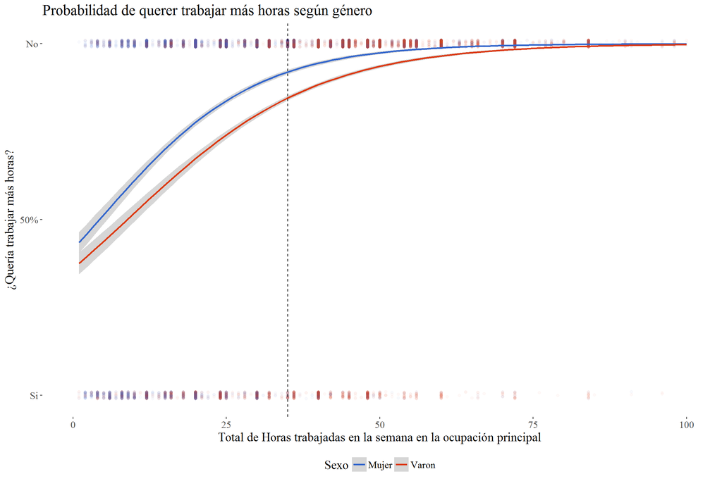

- la curva de la probabilidad de la respuesta negativa es siempre mayor en las mujeres que en los hombres para toda la distribución de horas trabajadas.
- Predominancia del género femenino en los valores más pequeños del eje x.
- ¿cómo afecta el género del individuo en el rol que se ocupa en el mercado de trabajo?
- La diferenciación por género en el mercado de trabajo no constituye únicamente una barrera de entrada, sino que continúa una vez adentro.

# Conclusiones

- Los resultados obtenidos muestran un gran potencial explicativo para este área de estudio, si bien no escapan a las dificultades.
- Muchos de los resultados obtenidos padecen de cierta trivialidad
- Se logró captar cierta ordinalidad no evidente en variables categóricas
- El resultado aportó evidencia sobre de la desigualdad de género que existe aún hoy en el mercado de trabajo

## Futuros trabajos

- Preguntas guía sean propias del contenido y no de la herramienta
- la problemática respecto al uso de los ponderadores tuvo sólo una respuesta parcial y requiere de estudios posteriores que tomen el tema en forma exclusiva para poder obtener respuestas más específicas en el asunto
- Aperturas por quintiles de ingreso
- Replicar el análisis a bases de datos de otros períodos para observar posibles cambios estructurales en la población.
- Complementar el análisis del rol de la mujer en el mercado de trabajo con un análisis del módulo *Organización del hogar* de la EPH, donde se pregunta respecto a quién realiza las tareas domésticas en el hogar.

# Bibliografía

Cuadras, C M. 2014. *Métodos de análisis multivariante*. doi:10.1017/CBO9781107415324.004.

Hastie, Trevor, Robert Tibshirani, y Jerome Friedman. 2009. *The Elements of Statistical Learning*. Vol. 1. doi:10.1007/b94608.

INDEC. 2016. «Encuesta Permanente de Hogares. Diseño de registro 4to trimestre 2016», 17.

Le Roux, Brigitte, y Henry Rouanet. 2010. *Quantitative applications in the social sciences*. Vols. 07-163.

Lê, Sébastien, Julie Josse, y François Husson. 2008. «{FactoMineR}: A Package for Multivariate Analysis». *Journal of Statistical Software* 25 (1): 1-18. doi:10.18637/jss.v025.i01.

Peña, Daniel. 2002. *Análisis de datos multivariantes*. December. doi:8448136101.

R Core Team. 2017. *R: A Language and Environment for Statistical Computing*. Vienna, Austria: R Foundation for Statistical Computing. https://www.r-project.org/.

Solon, Gary, Steven J Haider, y Jeffrey Wooldridge. 2015. «What Are We Weighting For?» *Journal of Human Resources* 50 (2): 301-16. doi:10.3386/w18859.

Vu, Vince. 2015. «ggbiplot». *GitHub repository*. https://github.com/vqv/ggbiplot.

Wickham, Hadley. 2009. *ggplot2: Elegant Graphics for Data Analysis*. Springer-Verlag New York. http://ggplot2.org.

Young, Rebekah. s. f. «Survey Sample Weights».